# Rendimiento y Riesgo

Rolando Fortanell

2025-02-11

## Explicacion

Ya sabemos que los comabios en el precio tienen un comportamiento dado por la EDE

$$dS=S\mu dt+S\sigma dW$$

Los valores de los parametros $\mu, \sigma$ dependen del tiempo, por lo cual debemos definir si seran diarios, seran anualizados o que caracteristicas vamos a considerar.

## Codigo

```r
library(quantmod)
library(lubridate)
clave <- "GFNORTEO.MX"
datos <- new.env()
getSymbols(clave, from="2000-01-02", to=today(), env=datos)
```

```
## [1] "GFNORTEO.MX"
```

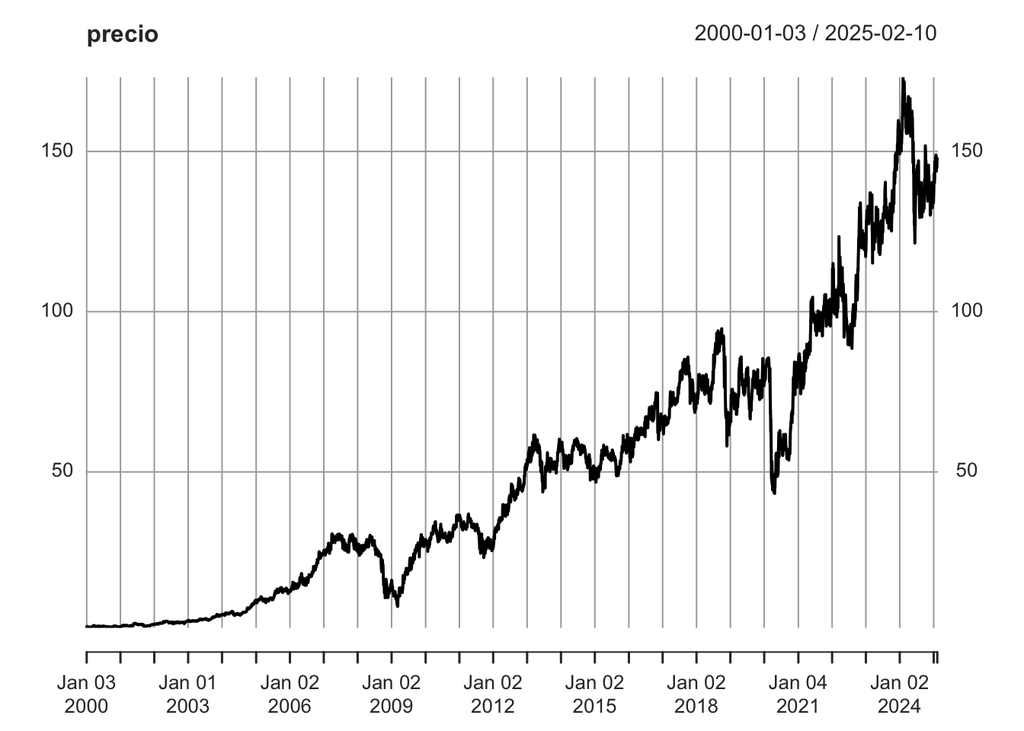

```r
precio <- datos[[clave]][,6]
plot(precio)
```

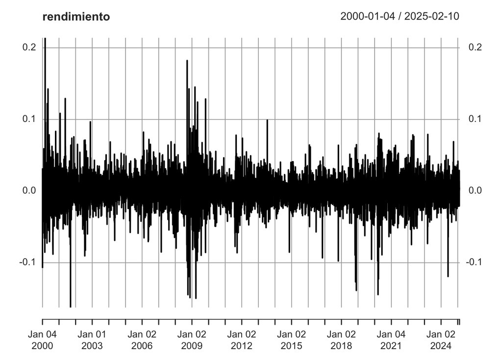

```r
rendimiento <- na.omit(diff(log(precio)))
plot(rendimiento)
```

Deciamos que los parametros dependen del tiempo, primero consideraremos los datos historicos, es decir todos los que existen

```r
mu_di_his <- mean(rendimiento)
sigma_di_hist <- sd(rendimiento)
mu_di_his
```

```
## [1] 0.0006874502
```

```r
sigma_di_hist
```

```
## [1] 0.02301177
```

Estos parametros podemos anualizarlos para que tengan una mejor interpretacion

```r
mu_anual_hist <- mean(rendimiento)*252
sigma_anual_hist <- sd(rendimiento)*sqrt(252)
mu_anual_hist
```

```
## [1] 0.1732374
```

```r
sigma_anual_hist
```

```
## [1] 0.3653006
```

Vamos a calcular estos mismos parametros para cada uno de los años de informacion que tenemos

```r
library(dplyr)
names(rendimiento) <- "rend"
tabla <- rendimiento %>%
  as_tibble() %>%
  mutate(anio=year(rendimiento)) %>%
  group_by(anio) %>%
  summarise("Rend_Diario"=mean(rend),
            "Vol_Diario"=sd(rend),
            "Ren_Anual"=mean(rend)*252,
            "Vol_Anual"=sd(rend)*sqrt(252))
```

Hasta ahora hemos considerado que los rendimientos tienen el supuesto de normalidad (esto sucede porque los rendimientos se explica por un proceso estocastico, que esta determinado por un epsilon que tiene media cero y varianza 1)

Veamos el historgrama del rendmiento

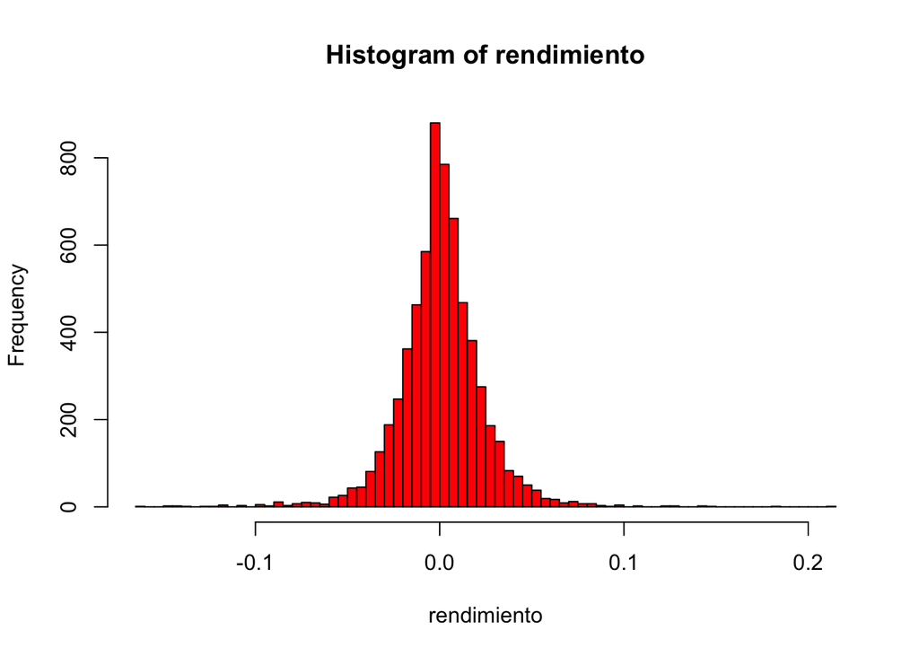

```r
hist(rendimiento, n=100, col="red")
```

Vamos a efectuar una prubea formal de NORMALIDAD. Una prueba formal nos indica, si estrictamente la variable sigue o no el comportamiento deseado. En este caso, la prueba que usaremos se llama Jarque-Bera y consiste en una prueba de hipotesi, con una nula y otra alternativa y usamos el valor del pvalue para decidir.

(NOTA: PARA MI PROYECTO TERCERA ENTREGA SERA NECESARIO QUE HAGA UNA PRUEBA DE NORMALIDAD, ENTONCES DEBO INVESTIGAR QUE ES LA PRUEBA, QUE CARACTERISTICA TIENE Y TODA LA INFORMACION RELEVANTE)

HO: HAY NORMALIDAD EN LOS DATOS HA: NO HAY NORMALIDAD

```r
library(moments)
jarque.test(as.numeric(rendimiento))
```

```
##
##  Jarque-Bera Normality Test
##
## data:  as.numeric(rendimiento)
## JB = 11885, p-value < 2.2e-16
## alternative hypothesis: greater
```

Haciendo la prueba de hipotesis llegamos a la conclusion que no existe normalidad debido a que existe leptocurtosis

La prueba que acabamos de hacer compara la distribucion de los datos que le damos con los de una normal, la normal tiene dos caracteristicas, sesgo cero y curtosis 3.

```r
skewness(rendimiento)
```

```
##        rend
## -0.02173153
```

```r
kurtosis(rendimiento)
```

```
##     rend
## 9.690029
```

```r
jarque.test(as.numeric(precio))
```

```
##
##  Jarque-Bera Normality Test
##
## data:  as.numeric(precio)
## JB = 730.43, p-value < 2.2e-16
## alternative hypothesis: greater
```

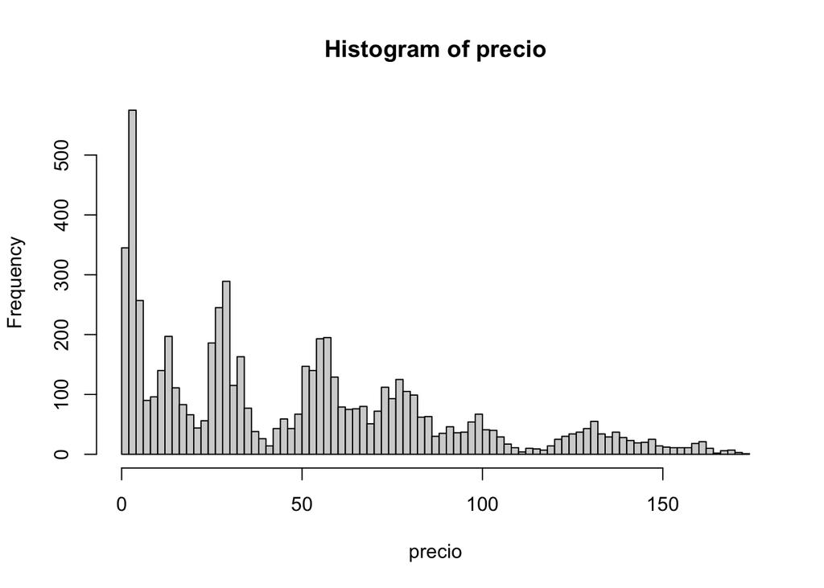

```r
hist(precio, n=100)
```

Ahora hagamos la prueba de rendimiento diario promedio igual a cero

Ho: La media del rendimiento diario es cero Ha: La media del rendimiento es diferente de cero

```r
t.test(as.numeric(rendimiento), mu=0, alternative = "two.sided")
```

```
##
##  One Sample t-test
##
## data:  as.numeric(rendimiento)
## t = 2.3849, df = 6372, p-value = 0.01711
## alternative hypothesis: true mean is not equal to 0
## 95 percent confidence interval:
##  0.0001223717 0.0012525286
## sample estimates:
##    mean of x
## 0.0006874502
```